# Proyecto: Reporte_RNAseq

Se analiza el resumen de las variables de interés para proceder con el proceso de limpieza de datos.

```r
# Poner atención particularmente en la variable de "tissue"
summary(as.data.frame(colData(rse_gene_SRP079058)[
  ,
  grepl("^sra_attribute.[cell_type|neoplastic|selection|tissue]", colnames(colData(rse_gene_SRP079058)))
]))
```

```
##     sra_attribute.cell_type sra_attribute.neoplastic sra_attribute.patient_id
##  Astocyte       :  88       Neoplastic:1091          BT_S1: 489
##  Immune cell    :1847       Regular   :2498          BT_S2:1169
##  Neoplastic     :1091                                BT_S4:1542
##  Neuron         :  21                                BT_S6: 389
##  Oligodendrocyte:  85
##  OPC            : 406
##  Vascular       :  51
##  sra_attribute.plate_id         sra_attribute.selection
##  Min.   :1.001e+09      Astrocytes(HEPACAM) : 714
##  1st Qu.:1.001e+09      Endothelial(BSC)    : 123
##  Median :1.001e+09      Microglia(CD45)     :1108
##  Mean   :1.001e+09      Neurons(Thy1)       : 685
##  3rd Qu.:1.001e+09      Oligodendrocytes(GC): 294
##  Max.   :1.001e+09      Unpanned            : 665
##
##  sra_attribute.source_name sra_attribute.tissue sra_attribute.tsne_cluster
##  Brain:3589                Periphery:1246       Min.   : 1.00
##                            Tumor    :2343       1st Qu.: 7.00
##                                                 Median : 8.00
##                                                 Mean   : 7.76
##                                                 3rd Qu.: 9.00
##                                                 Max.   :12.00
##
```

El siguiente paso es encontrar diferencias entre las variables de interés. En este caso se busca hacer un *Análisis de Expresión Diferencial (AED)* entre los genes expresados en tejidos tumorales o periféricos; información del apartado *sra_attribute.tissue*.

```r
# Nótese que el factor "tissue" ya cuenta con la clasificación adecuada para el objetivo: análisis de expresión difernecial entre tejidos cancerosos.
table(rse_gene_SRP079058$sra_attribute.tissue)
```

```
##
## Periphery     Tumor
##      1246      2343
```

A continuación se hace una operación para determinar la *proporción de fragmentos de interés*. Véase la documentación en: http://rna.recount.bio/docs/quality-check-fields.html

```r
# Hacer el cociente de interés para obtener la proporción de lecturas asignadas a genes
rse_gene_SRP079058$assigned_gene_prop <- rse_gene_SRP079058$recount_qc.gene_fc_count_all.assigned / rse_gene_SRP079058$recount_qc.gene_fc_count_all.total

# Al revisar el resumen de los datos resultantes se ve claramente que los datos no son de la mejor calidad, pues la media es 0.17956 y el tercer cuartil es 0.21188. Pero se ve que sí hay muestras de buena calidad con un máximo de 0.96298.
summary(rse_gene_SRP079058$assigned_gene_prop)
```

```
##    Min. 1st Qu.  Median    Mean 3rd Qu.    Max.
## 0.03743 0.12911 0.16379 0.17956 0.21188 0.96298
```

El siguiente paso es plotear esos primeros resultados de *assigned_gene_prop*.

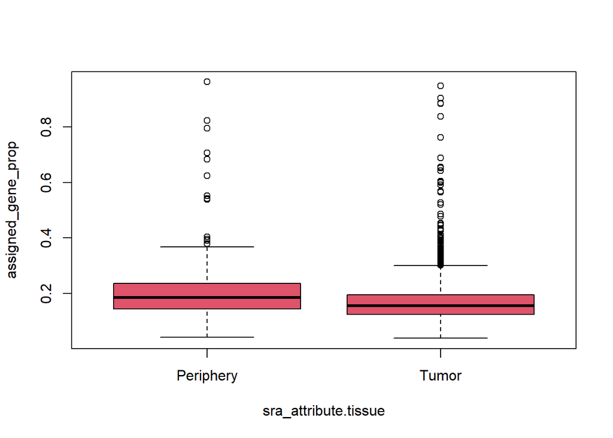

```r
with(colData(rse_gene_SRP079058), plot(x = sra_attribute.tissue,
                                       y = assigned_gene_prop,
                                       xlab = "sra_attribute.tissue",
                                       ylab = "assigned_gene_prop",
                                       col = sra_attribute.tissue))
```

```r
# Buscar diferencia entre los dos grupos de tejidos viendo sus estadísticas con "summary()"
with(colData(rse_gene_SRP079058), tapply(assigned_gene_prop, sra_attribute.tissue, summary))
```

```
## $Periphery
##    Min. 1st Qu.  Median    Mean 3rd Qu.    Max.
## 0.04144 0.14275 0.18491 0.19452 0.23585 0.96298
##
## $Tumor
##    Min. 1st Qu.  Median    Mean 3rd Qu.    Max.
## 0.03743 0.12378 0.15536 0.17161 0.19454 0.94821
```

Se puede visualizar para las otra variables de interés *cell_type|neoplastic|selection|tissue*.

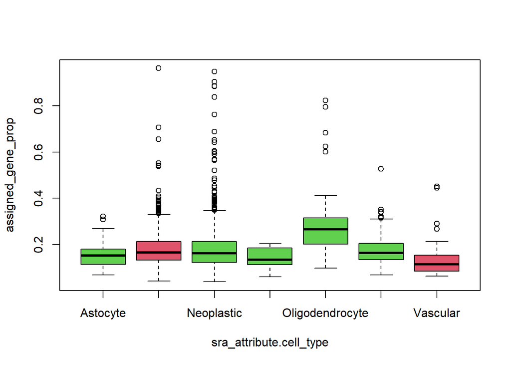

```r
with(colData(rse_gene_SRP079058), plot(x = sra_attribute.cell_type,
                                       y = assigned_gene_prop,
                                       xlab = "sra_attribute.cell_type",
                                       ylab = "assigned_gene_prop",
                                       col = sra_attribute.cell_type))
```

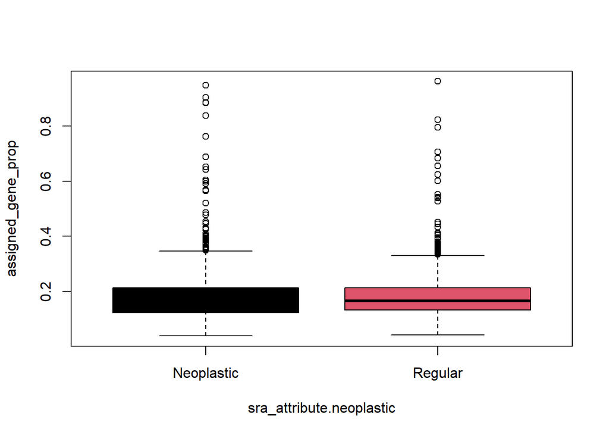

```r
with(colData(rse_gene_SRP079058), plot(x = sra_attribute.neoplastic,
                                       y = assigned_gene_prop,
                                       xlab = "sra_attribute.neoplastic",
                                       ylab = "assigned_gene_prop",
                                       col = sra_attribute.neoplastic))
```

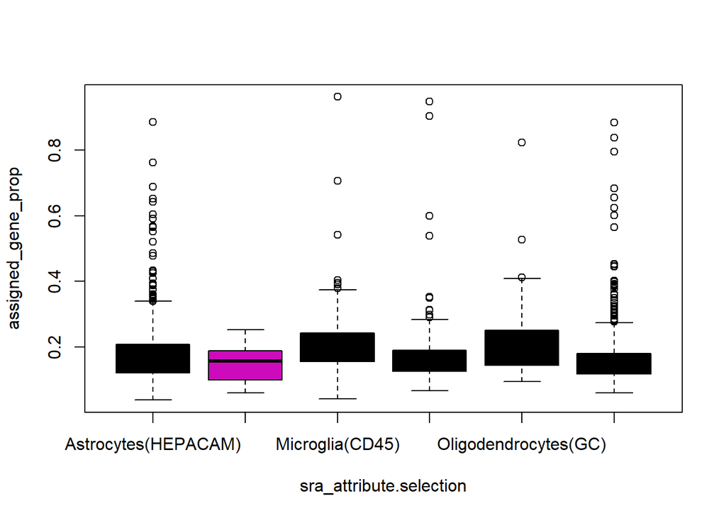

```r
with(colData(rse_gene_SRP079058), plot(x = sra_attribute.selection,
                                       y = assigned_gene_prop,
                                       xlab = "sra_attribute.selection",
                                       ylab = "assigned_gene_prop",
                                       col = sra_attribute.selection))
```

Se ve que, en general, todas las proporciones asignadas a genes son bajas en todas las variables de interés. Esto es indeseado porque se busca que los datos tengan la mejor calidad posible; desafortunadamente, la mayoría de los datos tienen baja calidad, por lo que será imposible purgar los datos sin comprometer la cantidad de los mismos a ser analizados.

Para poder comparar los datos sin filtrar originales y filtrados, se guardan los primeros en *rse_gene_SRP079058_unfiltered*.

```r
# Guardar antes de hacer limpieza
rse_gene_SRP079058_unfiltered <- rse_gene_SRP079058
# Nótese que me mantienen los 63856 genes y 3589 muestras.
rse_gene_SRP079058_unfiltered
```

```
## class: RangedSummarizedExperiment
## dim: 63856 3589
## metadata(8): time_created recount3_version ... annotation recount3_url
## assays(2): raw_counts counts
## rownames(63856): ENSG00000278704.1 ENSG00000277400.1 ...
##   ENSG00000182484.15_PAR_Y ENSG00000227159.8_PAR_Y
## rowData names(10): source type ... havana_gene tag
## colnames(3589): SRR3935092 SRR3936092 ... SRR3935999 SRR3936999
## colData names(186): rail_id external_id ... sra_attribute.well
##   assigned_gene_prop
```

Se puede proceder a la limpieza de datos. Por buena práctica y convencionalidad, se eliminan muestras y luego se eliminarán genes.

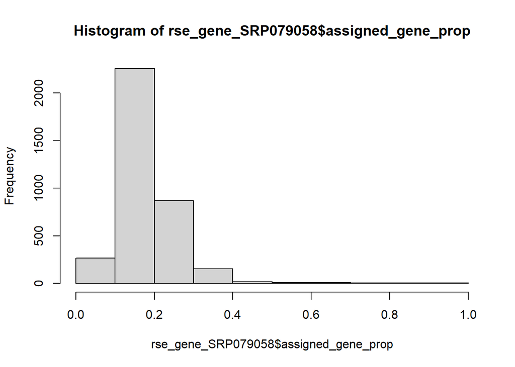

```r
#Primero visualizamos un histograma de la proporción de lecturas asignadas a genes. Los datos desde luego que parecen seguir una distribución Normal unimodal con la media en 0.1 < mu < 0.2, pues la media obtenida originalmente era 0.17956
hist(rse_gene_SRP079058$assigned_gene_prop)
```

Para ver el comportamiento y frecuencias de los datos de mejor calidad, se iguala el valor de corte a la media, con la finalidad de mover la media lo más posible hacia un valor de *assigned_gene_prop* mayor. La razón esencial de esta decisión es que, si no se eliminan las muestras con valores cercanos o menores a la media, la distribución no cambiará mucho debido a la enorme diferencia entre la frecuencia de muestras con valores de *assigned_gene_prop* bajos y altos.

```r
# Eliminemos muestras con valor menor a la media. Los resultados son radicales, pues se elimina la mitad de las muestras. Habrá que continuar con el análisis para decidir si mantener dicho cambio o no. Pues aunque se eliminan 2168/3589, las 1421 muestras restantes aun son un buen volumen con el cual trabajar y obtener buenos resultados.
table(rse_gene_SRP079058$assigned_gene_prop < summary(rse_gene_SRP079058$assigned_gene_prop)["Mean"])
```

```
##
## FALSE  TRUE
##  1421  2168
```

```r
# Rescatar muestras con assigned_gene_prop > 0.17956
rse_gene_SRP079058 <- rse_gene_SRP079058[, rse_gene_SRP079058$assigned_gene_prop > summary(rse_gene_SRP079058$assigned_gene_prop)["Mean"]]
# Se puede ver que ahora el objeto actualizado solo mantuvo 1421 muestras.
rse_gene_SRP079058
```

```
## class: RangedSummarizedExperiment
## dim: 63856 1421
## metadata(8): time_created recount3_version ... annotation recount3_url
## assays(2): raw_counts counts
## rownames(63856): ENSG00000278704.1 ENSG00000277400.1 ...
##   ENSG00000182484.15_PAR_Y ENSG00000227159.8_PAR_Y
## rowData names(10): source type ... havana_gene tag
## colnames(1421): SRR3935131 SRR3935162 ... SRR3935999 SRR3936999
## colData names(186): rail_id external_id ... sra_attribute.well
##   assigned_gene_prop
```

El siguiente paso es la eliminación de genes. Para ello se necesita calcular los *niveles medios de expresión* de los mismos en las muestras mantenidas.

```
##     Min.  1st Qu.   Median     Mean  3rd Qu.     Max.
##     0.00     0.00     0.05    12.09     2.31 67665.04
```

Ahora el mínimo se ha igualado a cero. Y es necesario eliminar aquellos genes por debajo de cierta expresión, en este caso la de la mediana.

```r
# Para asegurar rigor en el proceso se eliminan los genes por debajo de la mediana.
rse_gene_SRP079058 <- rse_gene_SRP079058[gene_means > summary(gene_means)["Median"], ]
# Revisar dimensiones finales. Las muestras pasaron de ser 3589->1421, y los genes fueron de 63856->31921
dim(rse_gene_SRP079058_unfiltered)
```

```
## [1] 63856  3589
```

```r
dim(rse_gene_SRP079058)
```

```
## [1] 31921  1421
```

Se puede revisar el porcentaje de genes que pasaron los criterios de limpieza.

```r
# Se retoma como punto de referencia "rse_gene_SRP079058_unfiltered" con todos los genes originales sin filtro ni limpieza. Aproximadamente la mitad de los genes prevalecieron.
round(nrow(rse_gene_SRP079058) / nrow(rse_gene_SRP079058_unfiltered)*100, 2)
```

```
## [1] 49.99
```

Eso quiere decir que se mantuvieron 49.99% de los genes originales. Véanse sus características de interés nuevamente.

```r
# Se revisan las nuevas estadísticas. En general, la media aumentó pero se mantiene en un valor relativamente bajo.
summary(rse_gene_SRP079058$assigned_gene_prop)
```

```
##    Min. 1st Qu.  Median    Mean 3rd Qu.    Max.
##  0.1796  0.2001  0.2280  0.2483  0.2677  0.9630
```

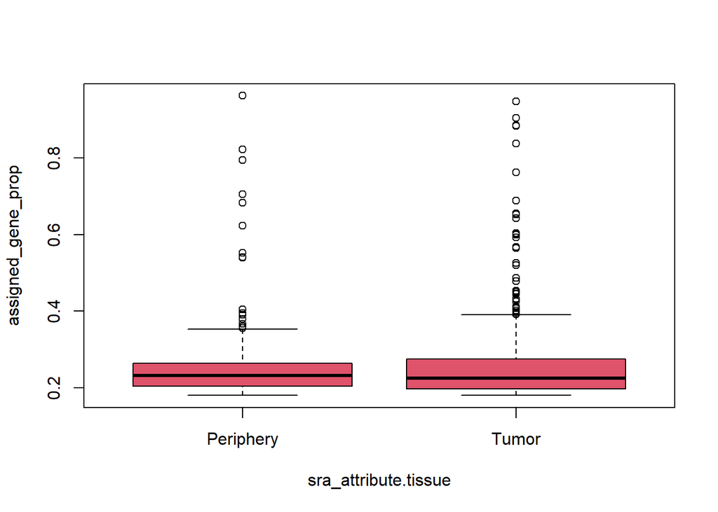

```r
with(colData(rse_gene_SRP079058), plot(x = sra_attribute.tissue,
                                       y = assigned_gene_prop,
                                       xlab = "sra_attribute.tissue",
                                       ylab = "assigned_gene_prop",
                                       col = sra_attribute.tissue))
```

Podemos ver que la media del puntaje sí mejoro, pero ínfimamente. Debido a que aún se tiene buena cantidad de datos, se propone una segunda limpieza con los mismos criterios que la enterior para la eliminación de muestras y genes.

```r
# Salvamos resultados del primer filtro
rse_gene_SRP079058_fil_1 <- rse_gene_SRP079058
# Corremos una segunda ronda de limpieza
# Eliminamos muestras
rse_gene_SRP079058 <- rse_gene_SRP079058[, rse_gene_SRP079058$assigned_gene_prop > summary(rse_gene_SRP079058$assigned_gene_prop)["Mean"]]
# Eliminamos genes
rse_gene_SRP079058 <- rse_gene_SRP079058[rowMeans(assay(rse_gene_SRP079058, "counts")) > summary(rowMeans(assay(rse_gene_SRP079058, "counts")))["Median"], ]
```

Ahora se comparan los datos previos con la segunda limpieza.

```r
# Comparamos tres objetos
summary(rse_gene_SRP079058_unfiltered$assigned_gene_prop)
```

```
##    Min. 1st Qu.  Median    Mean 3rd Qu.    Max.
## 0.03743 0.12911 0.16379 0.17956 0.21188 0.96298
```

```r
dim(rse_gene_SRP079058_unfiltered)
```

```
## [1] 63856  3589
```

```r
summary(rse_gene_SRP079058_fil_1$assigned_gene_prop)
```

```
##    Min. 1st Qu.  Median    Mean 3rd Qu.    Max.
##  0.1796  0.2001  0.2280  0.2483  0.2677  0.9630
```

```r
dim(rse_gene_SRP079058_fil_1)
```

```
## [1] 31921  1421
```

```r
summary(rse_gene_SRP079058$assigned_gene_prop)
```

```
##    Min. 1st Qu.  Median    Mean 3rd Qu.    Max.
##  0.2483  0.2632  0.2858  0.3169  0.3201  0.9630
```

```r
dim(rse_gene_SRP079058)
```

```
## [1] 15958   517
```

Se considera que la segunda limpieza mejoró la calidad de los datos para que todos sobrepasaran el *assigned_gene_prop > 0.2483*, lo cual se considera un buen criterio. No obstanete, hubo mucha información sacrificada. Por lo que queda decidir qué elección de datos usar para el resto del análisis.

El dataset final que se usará será el de la segunda limpieza. Con el fin de trabajar con los mejores datos; posee mucha menos información que los datos originales y tras la primera limpieza, pero aún mantiene buena cantidad de datos: 15958 genes & 517 muestras.

```r
# Guardamos los datos en una variable que especifica el segundo filtro.
rse_gene_SRP079058_fil_2 <- rse_gene_SRP079058
rse_gene_SRP079058_fil_2
```

```
## class: RangedSummarizedExperiment
## dim: 15958 517
## metadata(8): time_created recount3_version ... annotation recount3_url
## assays(2): raw_counts counts
## rownames(15958): ENSG00000227232.5 ENSG00000279457.4 ...
##   ENSG00000012817.15 ENSG00000198692.9
## rowData names(10): source type ... havana_gene tag
## colnames(517): SRR3935131 SRR3935263 ... SRR3935999 SRR3936999
## colData names(186): rail_id external_id ... sra_attribute.well
##   assigned_gene_prop
```

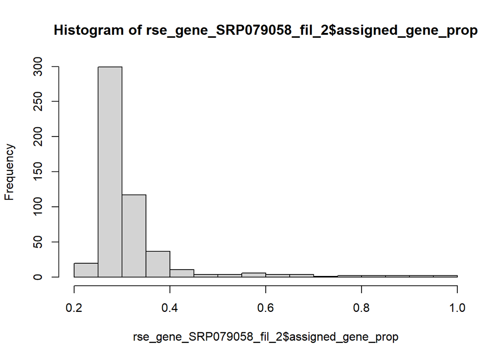

```r
# Se puede apreciar que la media creció y que la mayoría de datos tiene un puntaje < 0.4. Debido al gran sacrificio de datos que ya se realizaó con las dos limpiezas, ya no se realizarán más de las mismas.
hist(rse_gene_SRP079058_fil_2$assigned_gene_prop)
```

### Normalización

Una vez con los datos curados, se procede a la normalización de los mismos mediante la librería *edgeR*. Esta normalización se asegura de que los mismos niveles de expresión en dos muestras no sean detectados como Diferencialmente Expresados. Recordando que una heurística del método es la asunción de que la mayoría de los genes no están Diferencialmente Expresados.

```r
# Crear librería con el tipo de objeto DGEList adecuado.
dge <- DGEList(
  counts = assay(rse_gene_SRP079058_fil_2, "counts"),
  genes = rowData(rse_gene_SRP079058_fil_2)
)
# Convertir librería cruda en una de tamaño efectivo.
dge <- calcNormFactors(dge)
```

### Análisis de Expresión Diferencial

Se puede revisar la expresión en *rse_gene_SRP07905* con boxplots.

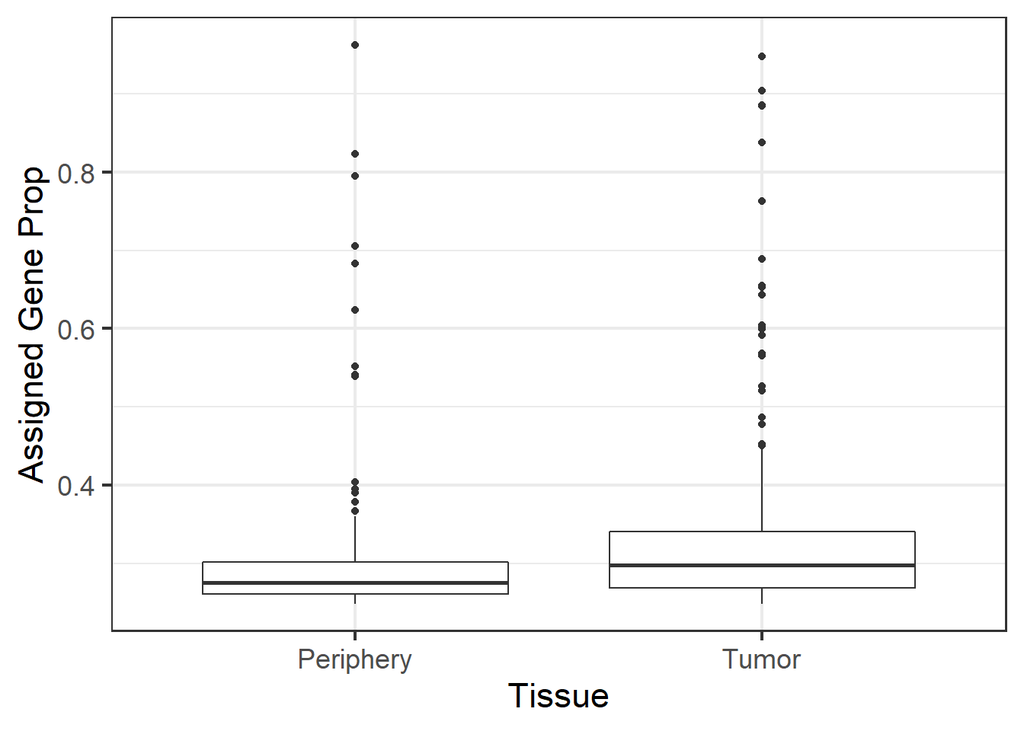

Ahora se crea un modelo estadístico pertinente. En esta ocasión se opta por uno simple para obtener resultados más directos. Pero nótese que aún así, las combinaciones dan un modelo complejo con 15 coeficientes.

```
##  [1] "(Intercept)"
##  [2] "sra_attribute.tissueTumor"
##  [3] "sra_attribute.neoplasticRegular"
##  [4] "sra_attribute.selectionEndothelial(BSC)"
##  [5] "sra_attribute.selectionMicroglia(CD45)"
##  [6] "sra_attribute.selectionNeurons(Thy1)"
##  [7] "sra_attribute.selectionOligodendrocytes(GC)"
##  [8] "sra_attribute.selectionUnpanned"
##  [9] "sra_attribute.cell_typeImmune cell"
## [10] "sra_attribute.cell_typeNeoplastic"
## [11] "sra_attribute.cell_typeNeuron"
## [12] "sra_attribute.cell_typeOligodendrocyte"
## [13] "sra_attribute.cell_typeOPC"
## [14] "sra_attribute.cell_typeVascular"
## [15] "assigned_gene_prop"
```

Ya se tiene el modelo estadístico, ahora se realiza el análisis de expresión diferencial con el paquete *limma*, el cual usa la distribución binomial negativa para modelar los datos. Para estimar sus coeficientes, se encuentran máximos (relativos) de forma iterativa.

```
## Coefficients not estimable: sra_attribute.cell_typeNeoplastic sra_attribute.cell_typeNeuron
```

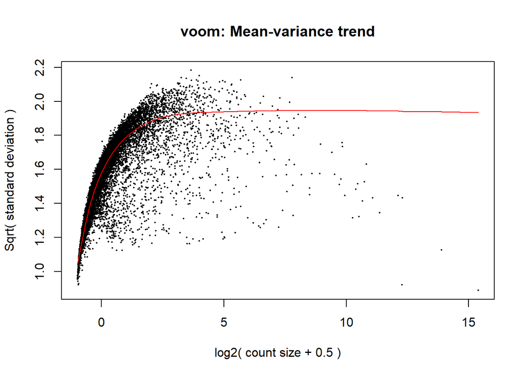

```r
# Usar "voom" como el método iterativo hasta converger.
vGene <- voom(dge, mod, plot = TRUE)
```

La gráfica de *voom* tiene los valores de expresión en el eje X y la varianza en el eje Y, y se puede apreciar un comportamiento asintótico favorable. Pero los estimados de varianza todavía pueden mejorarse, para aumentar la precisión de los resultados estadísticos.

```r
# Calcular t.Values con limma (t-Student)
eb_results <- eBayes(lmFit(vGene))
```

```
## Coefficients not estimable: sra_attribute.cell_typeNeoplastic sra_attribute.cell_typeNeuron
```

```r
# Seleccionar coeficiente de interés para "tissueTumor", con referencia a "tissuePeriphery" (Intercept). Recordar mantener el orden original.
de_results <- topTable(
  eb_results,
  coef = 2,
  number = nrow(rse_gene_SRP079058_fil_2),
  sort.by = "none"
)
# Revisar los resultados
# Se obtienen 16 columnas de interés para los 15958 genes.
dim(de_results)
```

```
## [1] 15958    16
```

```r
# Explorar resultados
head(de_results)
```

```
##                   source type bp_length phase           gene_id
## ENSG00000227232.5 HAVANA gene      1351    NA ENSG00000227232.5
## ENSG00000279457.4 HAVANA gene      1397    NA ENSG00000279457.4
## ENSG00000241670.3 HAVANA gene       457    NA ENSG00000241670.3
## ENSG00000228463.9 HAVANA gene      4039    NA ENSG00000228463.9
## ENSG00000225972.1 HAVANA gene       372    NA ENSG00000225972.1
## ENSG00000225630.1 HAVANA gene      1044    NA ENSG00000225630.1
##                                gene_type     gene_name level
## ENSG00000227232.5 unprocessed_pseudogene        WASH7P     2
## ENSG00000279457.4 unprocessed_pseudogene RP11-34P13.18     2
## ENSG00000241670.3   processed_pseudogene     RPL23AP21     1
## ENSG00000228463.9                lincRNA    AP006222.2     2
## ENSG00000225972.1 unprocessed_pseudogene      MTND1P23     2
## ENSG00000225630.1 unprocessed_pseudogene      MTND2P28     2
##                            havana_gene               tag      logFC   AveExpr
## ENSG00000227232.5 OTTHUMG00000000958.1              <NA> -1.0599247 0.7628755
## ENSG00000279457.4 OTTHUMG00000191963.1              <NA> -0.9214964 0.7945466
## ENSG00000241670.3 OTTHUMG00000002552.1 overlapping_locus -0.3123646 0.4458882
## ENSG00000228463.9 OTTHUMG00000002553.3 overlapping_locus -0.4413163 0.5851748
## ENSG00000225972.1 OTTHUMG00000002338.1              <NA> -0.2573954 6.0119826
## ENSG00000225630.1 OTTHUMG00000002336.1              <NA> -0.2874714 7.3204231
##                            t      P.Value    adj.P.Val         B
## ENSG00000227232.5 -5.7630234 1.416908e-08 1.245786e-07  9.275287
## ENSG00000279457.4 -4.6967332 3.387549e-06 1.340072e-05  4.127299
## ENSG00000241670.3 -1.7885911 7.426276e-02 1.011165e-01 -5.000156
## ENSG00000228463.9 -2.3519867 1.904546e-02 2.972395e-02 -3.828320
## ENSG00000225972.1 -1.1189228 2.636897e-01 3.135122e-01 -5.244942
## ENSG00000225630.1 -0.9165369 3.598103e-01 4.129937e-01 -5.431833
```

Ahora se deben rescatar los genes Diferencialmente Expresados entre *tissue.tumor* y *tissue.periphery*. Recordando el modelo *t = tissue.tumor - tissue.periphery*. Por convención se utilizará el *False Discovery Rate* con *FDR < 0.05*.

```r
# Purgar con base en P.Values.
table(de_results$adj.P.Val < 0.05)
```

```
##
## FALSE  TRUE
##  5069 10889
```

Los resultados dan 10889 genes Diferencialmente Expresados, un comportamiento esperado tieniendo en cuenta que la pregunta biológica base es la comparación de niveles de expresión de genes entre tejidos tumorales y periféricos de glioblastoma. Y desde luego que hay diferencia entre los genes expresados en ambos tejidos, puesto que el cancer es una enfermedad caracterizada por su complejidad genómica.

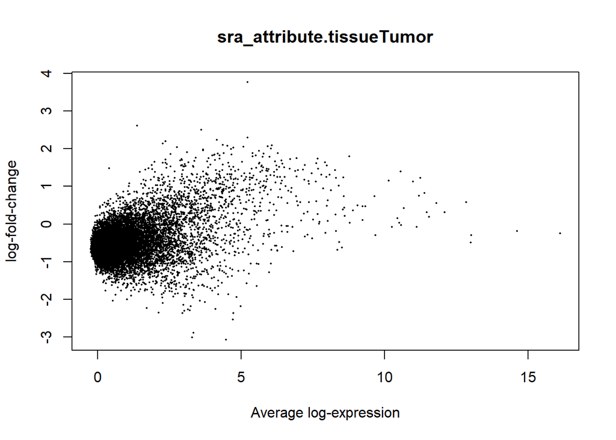

```r
# Ahora visualicemos los resultados estadísticos. Recordando que el coeficiente de interés es el 2: "tissueTumor"
plotMA(eb_results, coef = 2)
```

Al analizar el gráfico que compara el logFC y el promedio de expresión, se puede ver que los resultados se concentran un una zona particular con el *Average log-expression* entre 0 y 5; y el *logFC* principalmente entre -1 y 0.

También se puede visualizar con un *Volcano Plot*, que muestra el log2FC en eje X y -log(P.val). Buscando los valores con el -log(P.val) más alto que serán los más Diferencialmente Expresados.

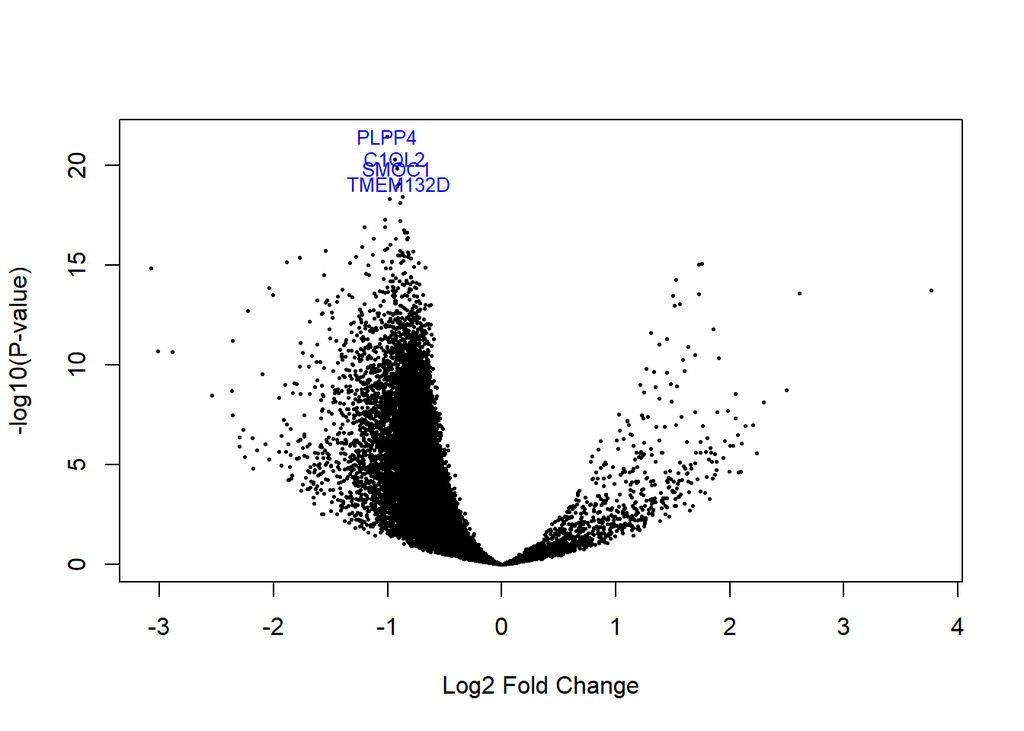

```r
# Seguir teniendo presente el coeficiente de interés 2: tissueTumor.
volcanoplot(eb_results, coef = 2, highlight = 4, names = de_results$gene_name)
```

Algo sumamente interesante es que la mayoría de los niveles de *log2FC* son negativos entre -1 y 0. Lo cual apunta a que la **Subexpresión Diferencial** de dichos genes son la principal diferencia entre tejido periférico y tumoral. Esto apunta a que la mayoría de los **los genes rescatados del dataset son genes supresores de tumores subexpresados en tejido tumoral.** Los cuatro genes rescatados con el volcano plot son:

- PLPP4 https://www.genecards.org/cgi-bin/carddisp.pl?gene=PLPP4
- C1QL2 https://www.genecards.org/cgi-bin/carddisp.pl?gene=C1QL2
- SMOC1 https://www.genecards.org/cgi-bin/carddisp.pl?gene=SMOC1
- TMEM132D https://www.genecards.org/cgi-bin/carddisp.pl?gene=TMEM132D

## Resultados

El siguiente paso es la visualización de los resultados: genes Diferencialmente Expresados.

```r
# Recuperar un número pertinente de genes con mayor Expresión Diferencial normalizada. Recordando que el parámetro es el P.val ajustado.
gene_number <- 50
expr_heatmap <- vGene$E[rank(de_results$adj.P.Val) <= gene_number, ]
# Extraer variables complementarias al análisis
df <- as.data.frame(colData(rse_gene_SRP079058_fil_2)[, c("sra_attribute.tissue", "sra_attribute.neoplastic", "sra_attribute.selection", "sra_attribute.cell_type")])
# Nombrar variables
colnames(df) <-c("Tissue", "Neoplastic", "Selection", "Cell_type")
# Visualizar df
head(df)
```

```
##               Tissue Neoplastic           Selection       Cell_type
## SRR3935131     Tumor Neoplastic Astrocytes(HEPACAM)      Neoplastic
## SRR3935263     Tumor Neoplastic       Neurons(Thy1)      Neoplastic
## SRR3935265     Tumor Neoplastic       Neurons(Thy1)      Neoplastic
## SRR3936275 Periphery    Regular            Unpanned Oligodendrocyte
## SRR3936277 Periphery    Regular            Unpanned Oligodendrocyte
## SRR3936278 Periphery    Regular            Unpanned Oligodendrocyte
```

Se puede continuar con la visualización gráfica de los resultados para extraer más conclusiones.

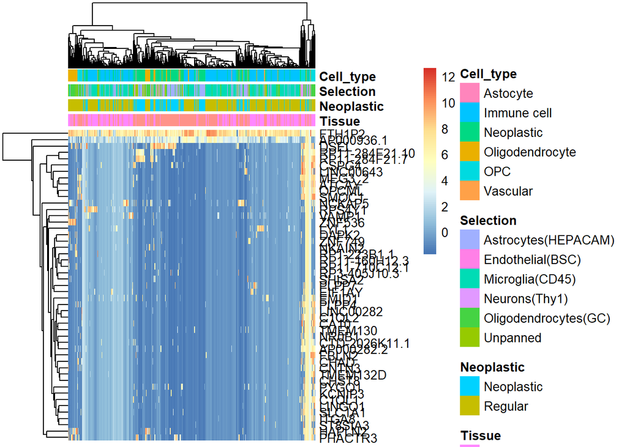

```r
# Obtener nombres de genes
rownames(expr_heatmap) <- rowRanges(rse_gene_SRP079058_fil_2)$gene_name[which(rank(de_results$adj.P.Val) <= gene_number)]
# Se hace un heatmap con clustering de genes y muestras.
pheatmap(
  expr_heatmap,
  cluster_rows = TRUE,
  cluster_cols = TRUE,
  show_rownames = TRUE,
  show_colnames = FALSE,
  annotation_col = df
)
```

Otro análisis interesante es el de *Principal Component Analisis (PCA)* entre las variables de interés. Primero puede ser sobre los tipos de tejido.

```r
# Seleccionar datos sobre tipo de tejido.
col.group <- df$Tissue
# Convertir los tejidos en colores
levels(col.group) <- brewer.pal(nlevels(col.group), "Set1")
```

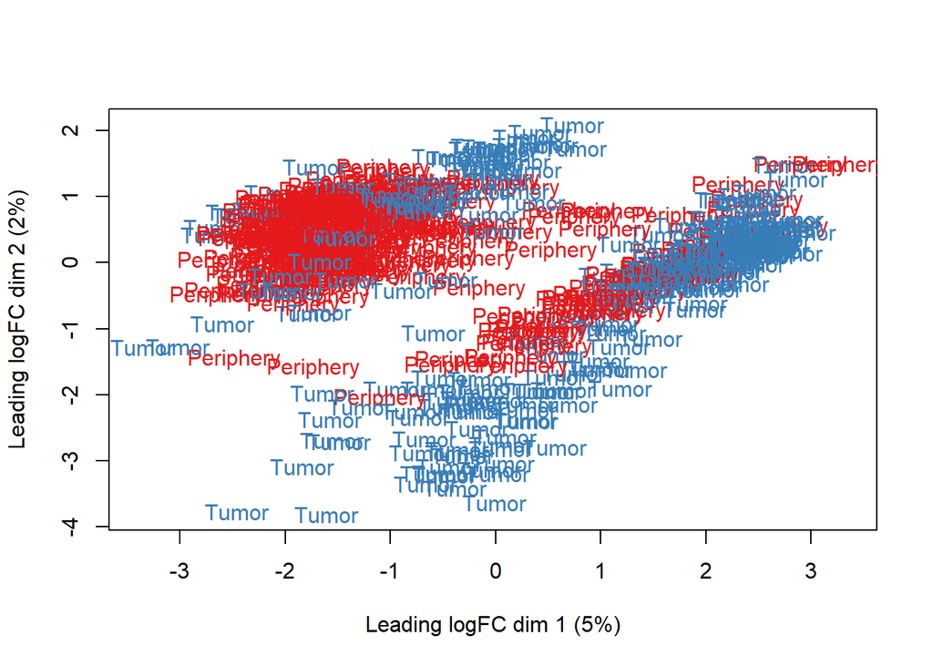

```r
# Convertir elementos en caracteres
col.group <- as.character(col.group)
# MDS por tipo de tejido
plotMDS(vGene$E, labels = df$Tissue, col = col.group)
```

También puede ser sobre el tipo celular.

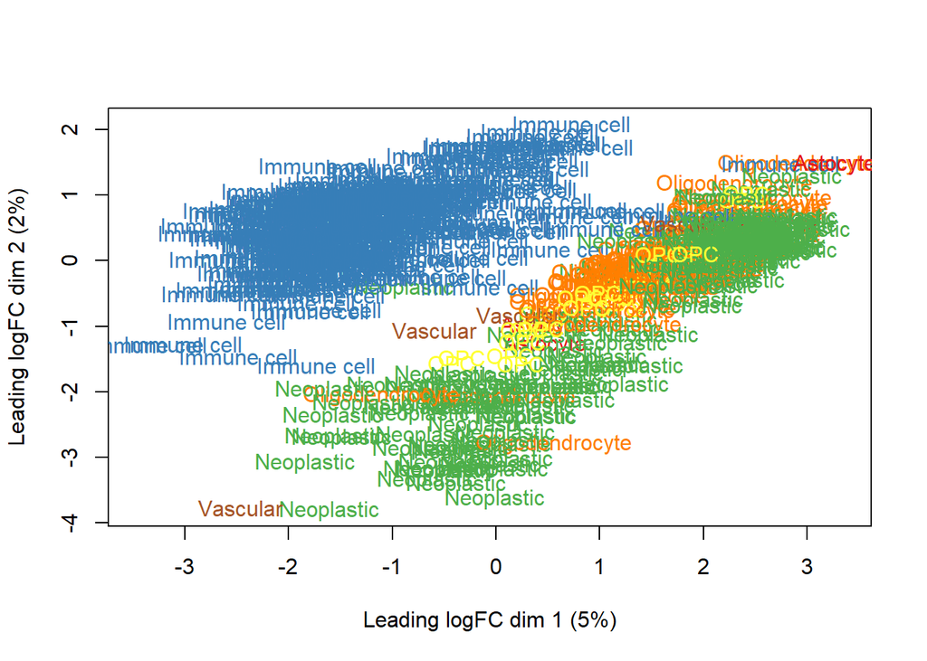

```r
# Seleccionar datos sobre tipo celular
col.group <- df$Cell_type
# Convertir los tipos celulares en colores
levels(col.group) <- brewer.pal(nlevels(col.group), "Set1")
# Convertir elementos en caracteres
col.group <- as.character(col.group)
# MDS por tipo celular
plotMDS(vGene$E, labels = df$Cell_type, col = col.group)
```

O sobre la selección celular.

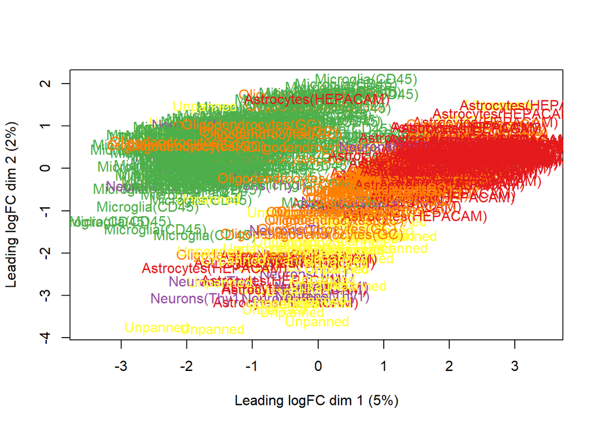

```r
# Seleccionar datos sobre selección
col.group <- df$Selection
# Convertir los tipos en colores
levels(col.group) <- brewer.pal(nlevels(col.group), "Set1")
# Convertir elementos en caracteres
col.group <- as.character(col.group)
# MDS por selección
plotMDS(vGene$E, labels = df$Selection, col = col.group)
```

O finalmente sobre el estado de neoplasticidad.

```r
# Seleccionar datos sobre neoplasticidad
col.group <- df$Neoplastic
# Convertir los estados en colores
levels(col.group) <- brewer.pal(nlevels(col.group), "Set1")
```

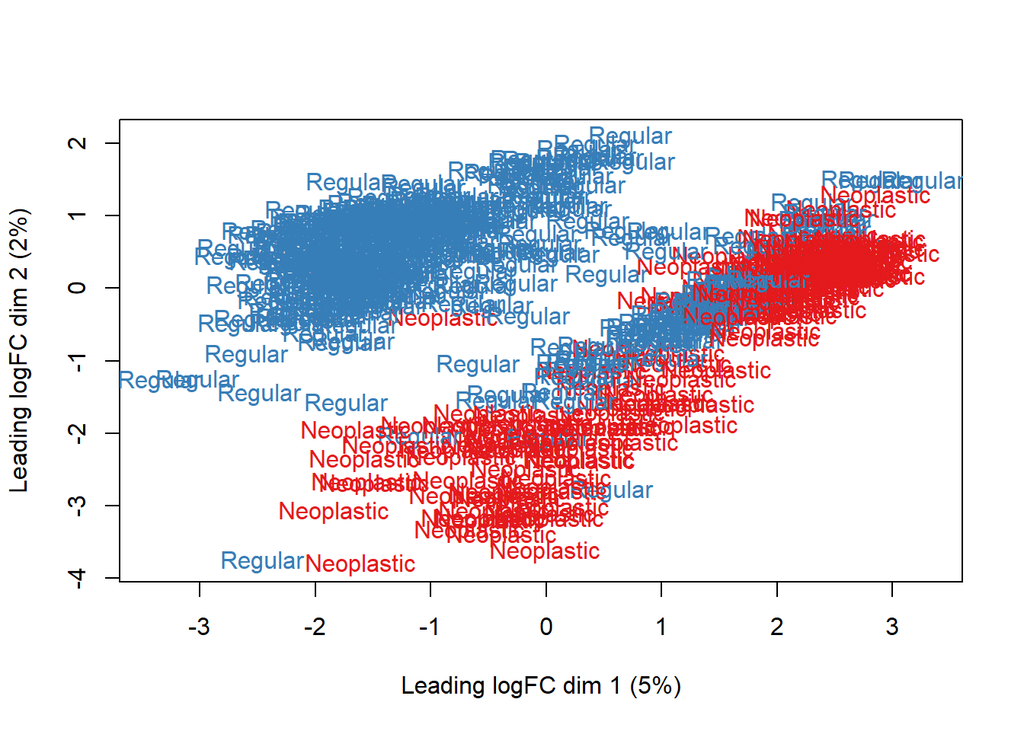

```r
# Convertir elementos en caracteres
col.group <- as.character(col.group)
# MDS por neoplasticidad
plotMDS(vGene$E, labels = df$Neoplastic, col = col.group)
```

## Discusión

Como se puede observar a lo largo de los 4 plots principales, los datos poseen una dirección pero con cierto ruido. En el primer plot, el heatmap, se puede observar que los genes más altamente expresados son muy escasos, y la mayoría tiene un nivel de expresión cercano a cero, o bien, están subexpresados. Este comportamiento seguramente tiene su base en la calidad de los datos, pues hay que recordar que el dataset fue sometido a dos rondas de limpieza a través de las cuales una considerable cantidad de información fue sacrificada. Esto puede indicar que, los cambios ligeros en los niveles de expresión de los genes son inherentes a la formación de glioblastoma; lo cual es algo totalmente plausible, puesto que ligera sobreexpresión o subexpresión de ciertos genes clave puede ser suficiente para desencadenar los procesos oncogénicos.

## Conclusiones

En conclusión, los *Análisis de Expresión Diferencial (AED)* son herramientas poderosas para hallar los niveles de expresión de genes en ciertas muestras de tejido o células; y pueden tener implicaciones en muchas áreas que van desde la investigación básica hasta la clínica. La actividad y regulación de genes es un fenómeno importante a lo largo de las diferentes ramas de las ciencias biológicas, y hacer uso de los recursos computaciones y de software es una estrategia muy eficiente para obtener los mejores resultados en su medición. Desde luego que un elemento de suma importancia en el análisis de *datos de secuenciación masiva*, y del *big data* en general, es la calidad y consistencia de los mismos datos; la base de todo.

Desde luego que metodologías tan complejas como esta deben ser llevadas a cabo cuidadosa y rigurosamente, pues todas las etapas para los mejores AED’s deben ser llevadas a cabo correctamente para asegurar la consistencia de todos los resultados; estas etapas van desde la pregunta de investigación planteada, la descarga de los datos, su limpieza, normalización, selección del modelo bioestadístico y consiguiente análisis. Por supuesto que la correcta interpretación de los resultados también es esencial, por lo que, además de saber usar las herramientas bioinformáticas y de software, también es menester tener los conocimientos biológicos necesarios.

Finalmente, es determinante subrayar la importancia de dichas herramientas bioinformáticas y bioestadísticas implementadas. La disponibilidad de software de bioinformática y los paquetes usados en este análisis por parte de *Bioconductor* (http://bioconductor.org/) fueron vitales. Es indudable que la continua disposición y creación de software de acceso libre está abriendo las puertas para experimentos y análisis *dry-lab*, que permiten la conexión de diversas disciplinas e ideas científicas a lo largo del mundo, permitiendo llegar cada vez más lejos y más rápido.

## Fuentes y ligas de interés

### Introducción

- 1.1) Le Rhun, Emilie; Preusser, Matthias; Roth, Patrick; Reardon, David A; van den Bent, Martin; Wen, Patrick; Reifenberger, Guido; Weller, Michael (2019). Molecular targeted therapy of glioblastoma. Cancer Treatment Reviews, 80:101896.
- 1.2) Wirsching HG, Galanis E, Weller M. Glioblastoma. Handb Clin Neurol. 2016;134:381-97. doi: 10.1016/B978-0-12-802997-8.00023-2. PMID: 26948367.

### Discusión

- 2.1) Sato Y, Honda Y, Asoh T, Oizumi K, Ohshima Y, Honda E. Cerebrospinal fluid ferritin in glioblastoma: evidence for tumor synthesis. J Neurooncol. 1998 Oct;40(1):47-50. doi: 10.1023/a:1006078521790. PMID: 9874185.
- 2.2) Jaksch-Bogensperger, H., Spiegl-Kreinecker, S., Arosio, P. et al. Ferritin in glioblastoma. Br J Cancer 122, 1441–1444 (2020). https://doi.org/10.1038/s41416-020-0808-8
- 2.3) Guo, Q., Li, L., Hou, S., Yuan, Z., Li, C., Zhang, W., Zheng, L., & Li, X. (2021). The Role of Iron in Cancer Progression. Frontiers in oncology, 11, 778492. https://doi.org/10.3389/fonc.2021.778492

### Documentación de Librerías

```
##
## Collado-Torres L (2022). _Explore and download data from the recount3
## project_. doi: 10.18129/B9.bioc.recount3 (URL:
## https://doi.org/10.18129/B9.bioc.recount3),
## https://github.com/LieberInstitute/recount3 - R package version 1.4.0,
## <URL: http://www.bioconductor.org/packages/recount3>.
##
## Wilks C, Zheng SC, Chen FY, Charles R, Solomon B, Ling JP, Imada EL,
## Zhang D, Joseph L, Leek JT, Jaffe AE, Nellore A, Collado-Torres L,
## Hansen KD, Langmead B (2021). "recount3: summaries and queries for
## large-scale RNA-seq expression and splicing." _bioRxiv_. doi:
## 10.1101/2021.05.21.445138 (URL:
## https://doi.org/10.1101/2021.05.21.445138), <URL:
## https://doi.org/10.1101/2021.05.21.445138>.
##
## To see these entries in BibTeX format, use 'print(<citation>,
## bibtex=TRUE)', 'toBibtex(.)', or set
## 'options(citation.bibtex.max=999)'.
```

```
##
## See Section 1.2 in the User's Guide for more detail about how to cite
## the different edgeR pipelines.
##
##   Robinson MD, McCarthy DJ and Smyth GK (2010). edgeR: a Bioconductor
##   package for differential expression analysis of digital gene
##   expression data. Bioinformatics 26, 139-140
##
##   McCarthy DJ, Chen Y and Smyth GK (2012). Differential expression
##   analysis of multifactor RNA-Seq experiments with respect to
##   biological variation. Nucleic Acids Research 40, 4288-4297
##
##   Chen Y, Lun ATL, Smyth GK (2016). From reads to genes to pathways:
##   differential expression analysis of RNA-Seq experiments using
##   Rsubread and the edgeR quasi-likelihood pipeline. F1000Research 5,
##   1438
##
## To see these entries in BibTeX format, use 'print(<citation>,
## bibtex=TRUE)', 'toBibtex(.)', or set
## 'options(citation.bibtex.max=999)'.
```

```
##
##
##   H. Wickham. ggplot2: Elegant Graphics for Data Analysis.
##   Springer-Verlag New York, 2016.
##
## A BibTeX entry for LaTeX users is
##
##   @Book{,
##     author = {Hadley Wickham},
##     title = {ggplot2: Elegant Graphics for Data Analysis},
##     publisher = {Springer-Verlag New York},
##     year = {2016},
##     isbn = {978-3-319-24277-4},
##     url = {https://ggplot2.tidyverse.org},
##   }
```

```
##
##
##   Raivo Kolde (2019). pheatmap: Pretty Heatmaps. R package version
##   1.0.12. https://CRAN.R-project.org/package=pheatmap
##
## A BibTeX entry for LaTeX users is
##
##   @Manual{,
##     title = {pheatmap: Pretty Heatmaps},
##     author = {Raivo Kolde},
##     year = {2019},
##     note = {R package version 1.0.12},
##     url = {https://CRAN.R-project.org/package=pheatmap},
##   }
##
## ATTENTION: This citation information has been auto-generated from the
## package DESCRIPTION file and may need manual editing, see
## 'help("citation")'.
```

```
##
##
##   Erich Neuwirth (2014). RColorBrewer: ColorBrewer Palettes. R package
##   version 1.1-2. https://CRAN.R-project.org/package=RColorBrewer
##
## A BibTeX entry for LaTeX users is
##
##   @Manual{,
##     title = {RColorBrewer: ColorBrewer Palettes},
##     author = {Erich Neuwirth},
##     year = {2014},
##     note = {R package version 1.1-2},
##     url = {https://CRAN.R-project.org/package=RColorBrewer},
##   }
```

```
##
## try to cite the appropriate methodology articles that describe the
## statistical methods implemented in limma, depending on which limma
## functions you are using.  The methodology articles are listed in
## Section 2.1 of the limma User's Guide.
##
##   Ritchie, M.E., Phipson, B., Wu, D., Hu, Y., Law, C.W., Shi, W., and
##   Smyth, G.K. (2015). limma powers differential expression analyses for
##   RNA-sequencing and microarray studies. Nucleic Acids Research 43(7),
##   e47.
##
## A BibTeX entry for LaTeX users is
##
##   @Article{,
##     author = {Matthew E Ritchie and Belinda Phipson and Di Wu and Yifang Hu and Charity W Law and Wei Shi and Gordon K Smyth},
##     title = {{limma} powers differential expression analyses for {RNA}-sequencing and microarray studies},
##     journal = {Nucleic Acids Research},
##     year = {2015},
##     volume = {43},
##     number = {7},
##     pages = {e47},
##     doi = {10.1093/nar/gkv007},
##   }
```